# Analytics Edge: Unit 2 - Linear Regression

Sulman Khan

October 26, 2018

## The Statisical Sommelier

### Bordeaux Wine

- Large differences in price and quality between years, although wine is produced in a similar way
- Meant to be aged, so hard to tell if wine will be good when it is on the market
- Can analytics be used to come up with a different system for judging wine?

### Building a Model

- March 1990 - Orley Ashenfelter, a Princeton economics professor, claims he can predict wine quality without tasting the wine
- Ashenfelter used a method called **linear regression**
  - Predicts an outcome variable, or dependent variable
  - Predicts using a set of independent variables
- Dependent variable: typical price in 1990-1991 wine auctions (approximates quality)
- Independent variables:
  - Age - older wines are more expensive
  - Weather
    - Average Growing Season Temperature
    - Harvest Rain
    - Winter Rain

### The Data (1952 - 1978)

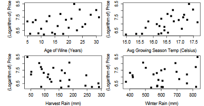

### One - Variable Linear Regression

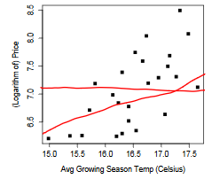

$$y = 7.07$$
$$y = 0.5(AGST) - 1.25$$

### The Regression Model

- One-variable regression model
  $$y^i = \beta_0 +\beta_1 x^i + \eta^i$$

y<sup>i</sup> = dependent variable (wine price) for the i<sup>th</sup> observation

x<sup>i</sup> = indepedent variable (temperature) for the i<sup>th</sup> observation

Eta<sup>i</sup> = error term for the i<sup>th</sup> observation

Beta_0 = intercept coefficient

Beta_1 = regression coefficient for the independent variable

### Selecting the Best Model

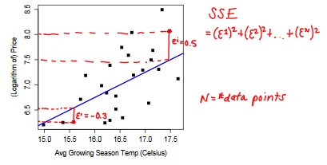

### R<sup>2</sup>

- Compares the best model to a “baseline” model
- The baseline model does not use any variables
  - Predicts same outcome (price) regardless of the independent variable (temperature)

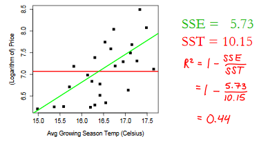

### Intepreting R<sup>2</sup>

$$R^2 = 1 - \frac{SSE}{SST}$$
* R<sup>2</sup> captures value added from using a model + R<sup>2</sup> = 0 means no improvement over baseline + R<sup>2</sup> = 1 means a perfect predictive model

### Multivariable Linear Regression

$$y^i = \beta_0 +\beta_1 x^i_1 + \beta_2 x^i_2 +... + \beta_k x^i_k + \eta^i$$

y<sup>i</sup> = dependent variable (wine price) for the i<sup>th</sup> observation

x<sup>i</sup>_j = j<sup>th</sup> indepedent variable (wine price) for the i<sup>th</sup> observation

Eta<sup>i</sup> = error term for the i<sup>th</sup> observation

Beta_0 = intercept coefficient

Beta_j = regression coefficient for the j<sup>th</sup> independent variable

- Best model coefficients selected to minimize SSE

### Adding Variables

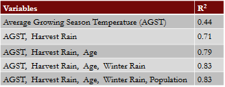

- Adding more variables can improve the model
- Diminishing returns as more variables are added

### Selecting Variables

- Not all available variables should be used
  - Each new variable requires more data
  - Causes **overfitting** high R<sup>2</sup> on data used to create model, but bad performance on unseen data

### Understanding the Model and Coefficients

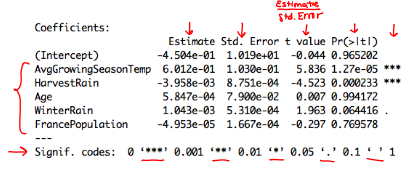

### Correlation

A measure of the linear relationship between variables

+1 = perfect positive linear relationship 0 = no linear relationship -1 = perfect negative linear relationship

### Examples of Correlation

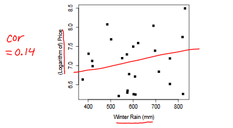

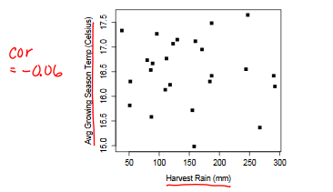

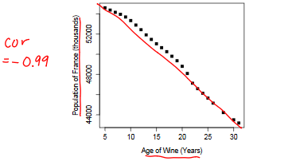

### Predictive Ability

- Our wine model has a value of R<sup>2</sup> = 0.83
- Tells us our accuracy on the data that we used to build the modle
- But how well does the model perform on new data?
  - Bordeaux wine buyers profit from being able to predict the quality of a wine years before it matures

### Out-of-Sample R<sup>2</sup>

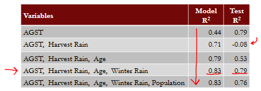

- Better model R<sup>2</sup> does not mean better test set R<sup>2</sup>
- Need more data to to be conclusive
- Out-of-sample R<sup>2</sup> can be negative!

### The Analytics Edge

- A linear regression model with only a few variables can predict wine prices fairly well
- In many cases, outperforms wine experts’ opinions
- A quantitative approach to a qualitative problem

## Linear Regression in R

### Read in data

```r
wine = read.csv("wine.csv")
str(wine)
```

```
## 'data.frame':    25 obs. of  7 variables:
##  $ Year       : int  1952 1953 1955 1957 1958 1959 1960 1961 1962 1963 ...
##  $ Price      : num  7.5 8.04 7.69 6.98 6.78 ...
##  $ WinterRain : int  600 690 502 420 582 485 763 830 697 608 ...
##  $ AGST       : num  17.1 16.7 17.1 16.1 16.4 ...
##  $ HarvestRain: int  160 80 130 110 187 187 290 38 52 155 ...
##  $ Age        : int  31 30 28 26 25 24 23 22 21 20 ...
##  $ FrancePop  : num  43184 43495 44218 45152 45654 ...
```

```r
summary(wine)
```

```
##       Year          Price         WinterRain         AGST        HarvestRain         Age         FrancePop
##  Min.   :1952   Min.   :6.205   Min.   :376.0   Min.   :14.98   Min.   : 38.0   Min.   : 5.0   Min.   :43184
##  1st Qu.:1960   1st Qu.:6.519   1st Qu.:536.0   1st Qu.:16.20   1st Qu.: 89.0   1st Qu.:11.0   1st Qu.:46584
##  Median :1966   Median :7.121   Median :600.0   Median :16.53   Median :130.0   Median :17.0   Median :50255
##  Mean   :1966   Mean   :7.067   Mean   :605.3   Mean   :16.51   Mean   :148.6   Mean   :17.2   Mean   :49694
##  3rd Qu.:1972   3rd Qu.:7.495   3rd Qu.:697.0   3rd Qu.:17.07   3rd Qu.:187.0   3rd Qu.:23.0   3rd Qu.:52894
##  Max.   :1978   Max.   :8.494   Max.   :830.0   Max.   :17.65   Max.   :292.0   Max.   :31.0   Max.   :54602
```

### Linear Regression

#### Linear Regression (one variable)

```r
model1 = lm(Price ~ AGST, data=wine)
summary(model1)
```

```
##
## Call:
## lm(formula = Price ~ AGST, data = wine)
##
## Residuals:
##      Min       1Q   Median       3Q      Max
## -0.78450 -0.23882 -0.03727  0.38992  0.90318
##
## Coefficients:
##             Estimate Std. Error t value Pr(>|t|)
## (Intercept)  -3.4178     2.4935  -1.371 0.183710
## AGST          0.6351     0.1509   4.208 0.000335 ***
## ---
## Signif. codes:  0 '***' 0.001 '**' 0.01 '*' 0.05 '.' 0.1 ' ' 1
##
## Residual standard error: 0.4993 on 23 degrees of freedom
## Multiple R-squared:  0.435,  Adjusted R-squared:  0.4105
## F-statistic: 17.71 on 1 and 23 DF,  p-value: 0.000335
```

#### Sum of Squared Errors

```r
model1$residuals
```

```
##           1           2           3           4           5           6           7           8           9          10          11          12          13
##  0.04204258  0.82983774  0.21169394  0.15609432 -0.23119140  0.38991701 -0.48959140  0.90318115  0.45372410  0.14887461 -0.23882157 -0.08974238  0.66185660
##          14          15          16          17          18          19          20          21          22          23          24          25
## -0.05211511 -0.62726647 -0.74714947  0.42113502 -0.03727441  0.10685278 -0.78450270 -0.64017590 -0.05508720 -0.67055321 -0.22040381  0.55866518
```

```r
SSE = sum(model1$residuals^2)
SSE
```

```
## [1] 5.734875
```

#### Linear Regression (two variables)

```r
model2 = lm(Price ~ AGST + HarvestRain, data=wine)
summary(model2)
```

```
##
## Call:
## lm(formula = Price ~ AGST + HarvestRain, data = wine)
##
## Residuals:
##      Min       1Q   Median       3Q      Max
## -0.88321 -0.19600  0.06178  0.15379  0.59722
##
## Coefficients:
##             Estimate Std. Error t value  Pr(>|t|)
## (Intercept) -2.20265    1.85443  -1.188  0.247585
## AGST         0.60262    0.11128   5.415 0.0000194 ***
## HarvestRain -0.00457    0.00101  -4.525  0.000167 ***
## ---
## Signif. codes:  0 '***' 0.001 '**' 0.01 '*' 0.05 '.' 0.1 ' ' 1
##
## Residual standard error: 0.3674 on 22 degrees of freedom
## Multiple R-squared:  0.7074, Adjusted R-squared:  0.6808
## F-statistic: 26.59 on 2 and 22 DF,  p-value: 0.000001347
```

#### Sum of Squared Errors

```r
SSE = sum(model2$residuals^2)
SSE
```

```
## [1] 2.970373
```

#### Linear Regression (all variables)

```r
model3 = lm(Price ~ AGST + HarvestRain + WinterRain + Age + FrancePop, data=wine)
summary(model3)
```

```
##
## Call:
## lm(formula = Price ~ AGST + HarvestRain + WinterRain + Age +
##     FrancePop, data = wine)
##
## Residuals:
##      Min       1Q   Median       3Q      Max
## -0.48179 -0.24662 -0.00726  0.22012  0.51987
##
## Coefficients:
##                Estimate  Std. Error t value  Pr(>|t|)
## (Intercept) -0.45039886 10.18888394  -0.044  0.965202
## AGST         0.60122388  0.10302027   5.836 0.0000127 ***
## HarvestRain -0.00395812  0.00087511  -4.523  0.000233 ***
## WinterRain   0.00104251  0.00053099   1.963  0.064416 .
## Age          0.00058475  0.07900313   0.007  0.994172
## FrancePop   -0.00004953  0.00016668  -0.297  0.769578
## ---
## Signif. codes:  0 '***' 0.001 '**' 0.01 '*' 0.05 '.' 0.1 ' ' 1
##
## Residual standard error: 0.3019 on 19 degrees of freedom
## Multiple R-squared:  0.8294, Adjusted R-squared:  0.7845
## F-statistic: 18.47 on 5 and 19 DF,  p-value: 0.000001044
```

#### Sum of Squared Errors

```r
SSE = sum(model3$residuals^2)
SSE
```

```
## [1] 1.732113
```

#### Remove FrancePop

```r
model4 = lm(Price ~ AGST + HarvestRain + WinterRain + Age, data=wine)
summary(model4)
```

```
##
## Call:
## lm(formula = Price ~ AGST + HarvestRain + WinterRain + Age, data = wine)
##
## Residuals:
##      Min       1Q   Median       3Q      Max
## -0.45470 -0.24273  0.00752  0.19773  0.53637
##
## Coefficients:
##               Estimate Std. Error t value  Pr(>|t|)
## (Intercept) -3.4299802  1.7658975  -1.942  0.066311 .
## AGST         0.6072093  0.0987022   6.152 0.0000052 ***
## HarvestRain -0.0039715  0.0008538  -4.652  0.000154 ***
## WinterRain   0.0010755  0.0005073   2.120  0.046694 *
## Age          0.0239308  0.0080969   2.956  0.007819 **
## ---
## Signif. codes:  0 '***' 0.001 '**' 0.01 '*' 0.05 '.' 0.1 ' ' 1
##
## Residual standard error: 0.295 on 20 degrees of freedom
## Multiple R-squared:  0.8286, Adjusted R-squared:  0.7943
## F-statistic: 24.17 on 4 and 20 DF,  p-value: 0.0000002036
```

#### Correlations

```r
cor(wine$WinterRain, wine$Price)
```

```
## [1] 0.1366505
```

```r
cor(wine$Age, wine$FrancePop)
```

```
## [1] -0.9944851
```

```r
cor(wine)
```

```
##                    Year      Price   WinterRain        AGST HarvestRain         Age    FrancePop
## Year         1.00000000 -0.4477679  0.016970024 -0.24691585  0.02800907 -1.00000000  0.994485097
## Price       -0.44776786  1.0000000  0.136650547  0.65956286 -0.56332190  0.44776786 -0.466861641
## WinterRain   0.01697002  0.1366505  1.000000000 -0.32109061 -0.27544085 -0.01697002 -0.001621627
## AGST        -0.24691585  0.6595629 -0.321090611  1.00000000 -0.06449593  0.24691585 -0.259162274
## HarvestRain  0.02800907 -0.5633219 -0.275440854 -0.06449593  1.00000000 -0.02800907  0.041264394
## Age         -1.00000000  0.4477679 -0.016970024  0.24691585 -0.02800907  1.00000000 -0.994485097
## FrancePop    0.99448510 -0.4668616 -0.001621627 -0.25916227  0.04126439 -0.99448510  1.000000000
```

#### Remove Age and FrancePop

```r
model5 = lm(Price ~ AGST + HarvestRain + WinterRain, data=wine)
summary(model5)
```

```
##
## Call:
## lm(formula = Price ~ AGST + HarvestRain + WinterRain, data = wine)
##
## Residuals:
##      Min       1Q   Median       3Q      Max
## -0.67472 -0.12958  0.01973  0.20751  0.63846
##
## Coefficients:
##               Estimate Std. Error t value   Pr(>|t|)
## (Intercept) -4.3016263  2.0366743  -2.112   0.046831 *
## AGST         0.6810242  0.1117011   6.097 0.00000475 ***
## HarvestRain -0.0039481  0.0009987  -3.953   0.000726 ***
## WinterRain   0.0011765  0.0005920   1.987   0.060097 .
## ---
## Signif. codes:  0 '***' 0.001 '**' 0.01 '*' 0.05 '.' 0.1 ' ' 1
##
## Residual standard error: 0.345 on 21 degrees of freedom
## Multiple R-squared:  0.7537, Adjusted R-squared:  0.7185
## F-statistic: 21.42 on 3 and 21 DF,  p-value: 0.000001359
```

#### Read in test set

```r
wineTest = read.csv("wine_test.csv")
str(wineTest)
```

```
## 'data.frame':    2 obs. of  7 variables:
##  $ Year       : int  1979 1980
##  $ Price      : num  6.95 6.5
##  $ WinterRain : int  717 578
##  $ AGST       : num  16.2 16
##  $ HarvestRain: int  122 74
##  $ Age        : int  4 3
##  $ FrancePop  : num  54836 55110
```

#### Make test set predictions

```r
predictTest = predict(model4, newdata=wineTest)
predictTest
```

```
##        1        2
## 6.768925 6.684910
```

#### Compute R-squared

```r
SSE = sum((wineTest$Price - predictTest)^2)
SST = sum((wineTest$Price - mean(wine$Price))^2)
1 - SSE/SST
```

```
## [1] 0.7944278
```